# Lab 7: Functions and Fish

Author

Antonio da Silva

```r
library(tidyverse)
library(here)
library(dplyr)

BlackfootFish <- read_csv(here::here("Week 7", "Lab7", "BlackfootFish.csv"))
```

## **2 Part One: Summaries and Plots (Midterm Review)**

**Task 1 – Summarizing Missing Data**

The measurements of each fish captured were taken by a Biologist on a raft. This lack of “laboratory setting” opens the door to the possibility of measurement errors.

- How many observations have missing values?
- What variable(s) have missing values present?

**Output both pieces of information in *one* table!**

```r
BlackfootFish |>
  summarize((across(
    .cols = trip:species,
    .fns = ~sum(is.na(.)))))
```

```
# A tibble: 1 × 7
   trip  mark length weight  year section species
  <int> <int>  <int>  <int> <int>   <int>   <int>
1     0     0      0   1796     0       0       0
```

### **Task 2 – Visualizing Missing Data**

Unfortunately, these missing values are not for only one `year`, `trip`, or `section` of river.

Create a thoughtful visualization exploring the frequency of missing values across the different years, sections, and trips.

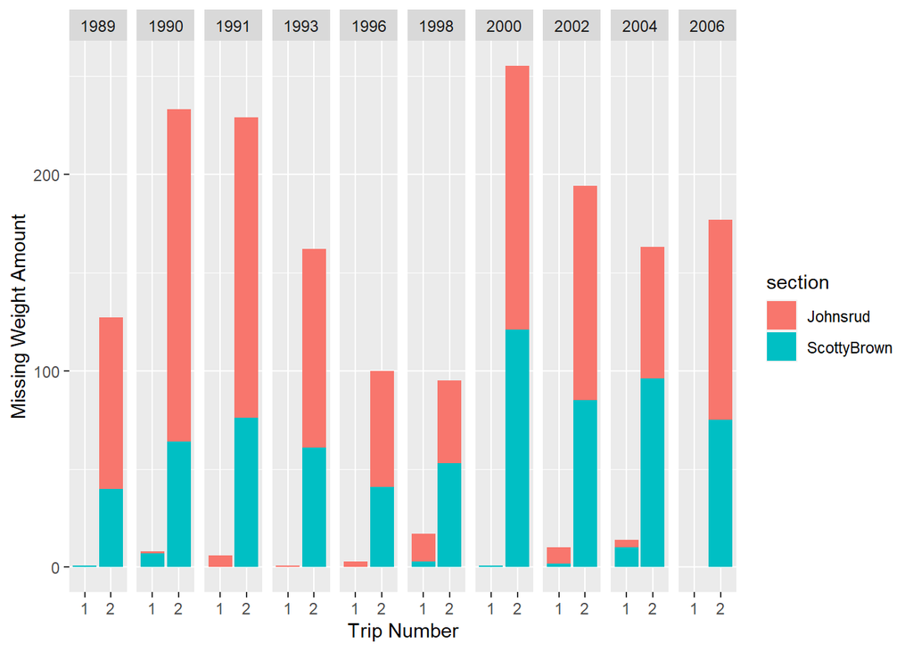

```r
BlackfootFish |>
  select(year, trip, section, weight) |>
  mutate(weight = is.na(weight),
         trip = as.factor(trip)) |>
  group_by(year, section, trip) |>
  summarize(weight = sum(weight))|>
  ggplot(mapping = aes(x = trip, y = weight, fill = section)) +
  geom_col() +
  labs(x = "Trip Number", y = "Missing Weight Amount") +
  facet_grid(~year)
```

## **3 Part Two: Adjusting the Data (Function Writing)**

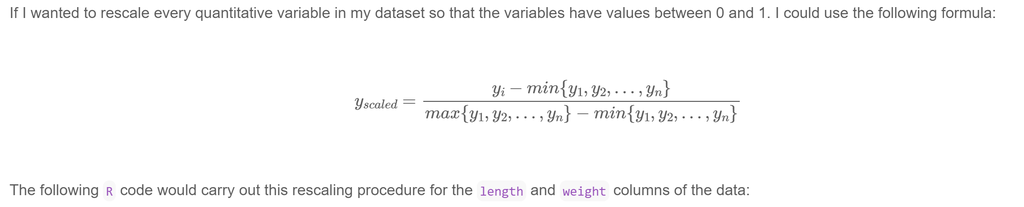

```r
BlackfootFish |>
  mutate(length = (length - min(length, na.rm = TRUE)) /
           (max(length, na.rm = TRUE) - min(length)),
         weight = (weight - min(weight, na.rm = TRUE)) /
           (max(weight, na.rm = TRUE) - min(length, na.rm = TRUE))
         )
```

```
# A tibble: 18,352 × 7
    trip  mark length  weight  year section  species
   <dbl> <dbl>  <dbl>   <dbl> <dbl> <chr>    <chr>
 1     1     0  0.280 0.0374   1989 Johnsrud RBT
 2     1     0  0.280 0.0406   1989 Johnsrud RBT
 3     1     0  0.277 0.0524   1989 Johnsrud RBT
 4     1     0  0.315 0.0588   1989 Johnsrud RBT
 5     1     0  0.305 0.0641   1989 Johnsrud RBT
 6     1     0  0.358 0.0812   1989 Johnsrud RBT
 7     1     0  0.261 0.0363   1989 Johnsrud RBT
 8     1     0  0.148 0.00855  1989 Johnsrud RBT
 9     1     0  0.203 0.0171   1989 Johnsrud RBT
10     1     0  0.145 0.00748  1989 Johnsrud RBT
# … with 18,342 more rows
```

This process of duplicating an action multiple times makes it difficult to understand the intent of the process. Additionally, it makes it very difficult to spot the mistakes. *Did you spot the mistake in the weight conversion?*

Often you will find yourself in the position of needing to find a function that performs a specific task, but you do not know of a function or a library that would help you. You could spend time Googling for a solution, but in the amount of time it takes you to find something you could have already written your own function!

### **Task 1 – Writing a Function**

Let’s transform the repeated process above into a `rescale_01()` function.

- The function should take a single vector as its input.
- The function should return the rescaled vector.

*Think about the “efficiency” of your function. Are you calling the **same** function multiple times?*

```r
rescale_01 <- function(input){

  z <- (input - min(input, na.rm = TRUE)) / (max(input, na.rm = TRUE) - min(input, na.rm = TRUE))

      return(z)
}

test <- c(1:25, NA)

rescale_01(test)
```

```
 [1] 0.00000000 0.04166667 0.08333333 0.12500000 0.16666667 0.20833333
 [7] 0.25000000 0.29166667 0.33333333 0.37500000 0.41666667 0.45833333
[13] 0.50000000 0.54166667 0.58333333 0.62500000 0.66666667 0.70833333
[19] 0.75000000 0.79166667 0.83333333 0.87500000 0.91666667 0.95833333
[25] 1.00000000         NA
```

### **Task 2 – Adding Stops**

Now, let’s incorporate some checks into your function! Modify your previous code to create the following checks:

- the function should stop if the input vector is not numeric
- the function should stop if the length of the vector is not greater than 1

*No need to write code here, simply add these stops to your code from Task 1!*

```r
rescale_01 <- function(input) {
  stopifnot(is.numeric(input),
            length(input) > 1)

  rng <- range(input, na.rm = TRUE, finite = TRUE)
  (input - rng[1]) / (rng[2] - rng[1])
}
x <- c(1:25, NA)
rescale_01(x)
```

```
 [1] 0.00000000 0.04166667 0.08333333 0.12500000 0.16666667 0.20833333
 [7] 0.25000000 0.29166667 0.33333333 0.37500000 0.41666667 0.45833333
[13] 0.50000000 0.54166667 0.58333333 0.62500000 0.66666667 0.70833333
[19] 0.75000000 0.79166667 0.83333333 0.87500000 0.91666667 0.95833333
[25] 1.00000000         NA
```

### **Task 3 - Performing a Simple Test**

First, test your function on the simple vector below. Verify that the maximum of your rescaled vector is 1 and the minimum is 0!

```r
x <- c(1:25, NA)
rescale_01(x)
```

```
 [1] 0.00000000 0.04166667 0.08333333 0.12500000 0.16666667 0.20833333
 [7] 0.25000000 0.29166667 0.33333333 0.37500000 0.41666667 0.45833333
[13] 0.50000000 0.54166667 0.58333333 0.62500000 0.66666667 0.70833333
[19] 0.75000000 0.79166667 0.83333333 0.87500000 0.91666667 0.95833333
[25] 1.00000000         NA
```

### **Task 4 - Performing a More Difficult Test**

Next, let’s test the function on the `length` column of the `BlackfootFish` dataset.

Make plots of the original values of `length` and the rescaled values of `length`. Output your plots side-by-side, so the reader can confirm the only aspect that has changed is the scale.

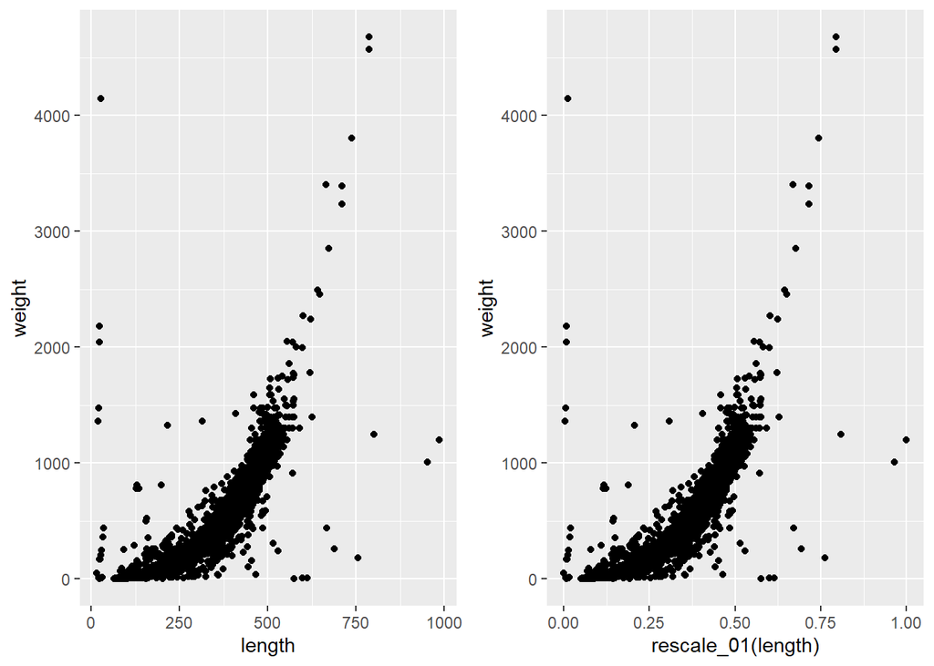

```r
library(gridExtra)

length_plot <- BlackfootFish |>
  mutate(new_length = rescale_01(length)) |>
  ggplot(length_plot, mapping = aes(x = length, y = weight)) +
  geom_point() +
  labs()

newlength_plot <-  BlackfootFish |>
  mutate(new_length = rescale_01(length)) |>
  ggplot(length_plot, mapping = aes(x = new_length, y = weight)) +
  geom_point() +
  labs(x = "rescale_01(length)")

grid.arrange(length_plot, newlength_plot, nrow = 1)
```

### **Task 5 – Incorporating Variables**

Suppose you would like for your `rescale()` function to perform operations on a variable within a dataset. Ideally, your function would take a dataframe and a variable name as inputs and return a dataframe where the variable has been rescaled.

Create a `rescale_column()` that accepts two arguments, (1) a dataframe, and (2) the name(s) of the variable(s) to be rescaled. The body of the function should call the original `rescale_01()` function you wrote previously.

*Hint:* If you are struggling with this task, I would recommend reading the [Data frame functions](https://r4ds.hadley.nz/functions.html#data-frame-functions) section from the new R for Data Science book.

```r
rescale_column <- function(data, variable) {
  stopifnot(is.data.frame(data))

   data %>%
    mutate(
      across(.cols = {{ variable }}, .fns = rescale_01
      )
    )

}
```

### **Task 6 – Another Function Test**

Alright, now let’s put your `rescale_column()` function to work! Use your `rescale_column()` function to rescale **both** the `length` and `weight` columns.

**I expect that you carry out this process by calling the `rescale()` function *one* time!**

*Note:* I advise against using functions like `mutate_at()`, which have been superseded.

```r
rescale_column(BlackfootFish, length:weight)
```

```
# A tibble: 18,352 × 7
    trip  mark length  weight  year section  species
   <dbl> <dbl>  <dbl>   <dbl> <dbl> <chr>    <chr>
 1     1     0  0.280 0.0374   1989 Johnsrud RBT
 2     1     0  0.280 0.0406   1989 Johnsrud RBT
 3     1     0  0.277 0.0524   1989 Johnsrud RBT
 4     1     0  0.315 0.0588   1989 Johnsrud RBT
 5     1     0  0.305 0.0641   1989 Johnsrud RBT
 6     1     0  0.358 0.0812   1989 Johnsrud RBT
 7     1     0  0.261 0.0363   1989 Johnsrud RBT
 8     1     0  0.148 0.00855  1989 Johnsrud RBT
 9     1     0  0.203 0.0171   1989 Johnsrud RBT
10     1     0  0.145 0.00748  1989 Johnsrud RBT
# … with 18,342 more rows
```